# Start codon context for Saccharomyces cerevisiae

Edward Wallace, ewjwallace@gmail.com

16 Jan 2019

# Summary

This presents the renewed analysis of Saccharomyces start codon usage and context. This uses the S. cerevisiae S288C expression estimates from Csardi et al 2015, and translation estimates from Geraschenko and Gladyshev 2014.

This document was started in Aug 2018, updated through Jan 2019, and used as a template for the analyses in other fungi.

# Here we go

## Expression: RNA abundance and ribosome-protected-fragments

### Load expression data

```
## # A tibble: 5,564 x 7
##    GeneAlt                 Gene       RPF Gene2    RNA     Prot    TE
##    <chr>                   <chr>    <dbl> <chr>  <dbl>    <dbl> <dbl>
##  1 YBR118W_YPR080W         YBR118W 11128. TEF2   70.5    98315. 158.
##  2 YKL060C                 YKL060C 10411. FBA1  253.   1290812.  41.1
##  3 YAL038W                 YAL038W  9489. CDC19 152.    283439.  62.3
##  4 YCR012W                 YCR012W  9132. PGK1  180.    702621.  50.6
##  5 YGR254W_YHR174W         YGR254W  9095. ENO1   50.9   102394. 179.
##  6 YGR192C_YJR009C_YJL052W YGR192C  9030. TDH3  142.    719496.  63.4
##  7 YKL152C                 YKL152C  8405. GPM1  176.    367415.  47.9
##  8 YLR110C                 YLR110C  8230. CCW12  87.7   140281.  93.8
##  9 YJL189W                 YJL189W  6544. RPL39  26.1     7215. 251.
## 10 YLR134W_YLR044C         YLR134W  6426. PDC5    6.96    7270. 924.
## # ... with 5,554 more rows
```

We also calculated hiTrans, the top 5% (300) translated genes by RPF TPM.

### Ribosome occupancy mostly tracks RNA abundance

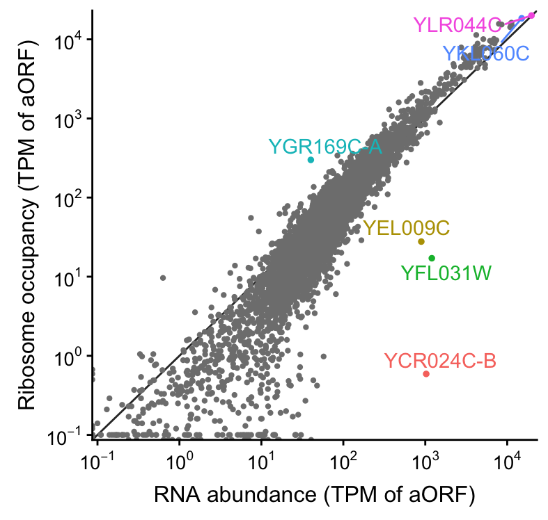

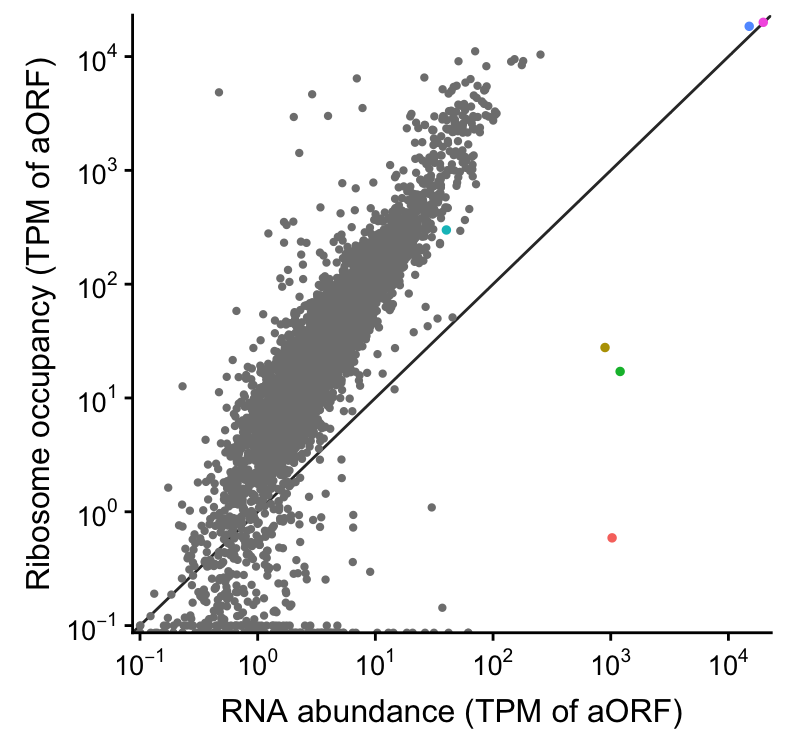

## ATG Context

### Load context data

```
## # A tibble: 6,571 x 19
##    Gene  aATG.context aATG.pos d1.context d1.posTSS d1.posATG d1.frame
##    <chr> <chr>           <dbl> <chr>          <dbl>     <dbl>    <dbl>
##  1 YAL0… GCCACAAGAAA…        1 GTTCGTGCT…       153       152        2
##  2 YAL0… ATTACACCTAG…        1 gaATGGAGC…        11        10        1
##  3 YAL0… TATACACACAT…       51 AGAATTCTC…       200       149        2
##  4 YAL0… TTCACCACCCA…        1 ATACCGTCT…        47        46        1
##  5 YAL0… ATAACAGATAA…       63 CTCACTTTG…       124        61        1
##  6 YAL0… TAAAGGAAAAC…       76 CATCTTCCA…       161        85        1
##  7 YAL0… AATAGGTGTAA…       98 TTGGCTTTT…       116        18        0
##  8 YAL0… ATAAAGGAGGT…        1 AGAGCATAG…        23        22        1
##  9 YAL0… AGACCGATCTT…       42 ATGCTACCC…        54        12        0
## 10 YAL0… AGACAAGTAAG…        3 GTGGTCGTG…       106       103        1
## # ... with 6,561 more rows, and 12 more variables: d2.context <chr>,
## #   d2.posTSS <dbl>, d2.posATG <dbl>, d2.frame <dbl>, u1.context <chr>,
## #   u1.posTSS <dbl>, u1.posATG <dbl>, u1.frame <dbl>, u2.context <chr>,
## #   u2.posTSS <dbl>, u2.posATG <dbl>, u2.frame <dbl>
```

### Annotated ATGs have a Kozak consensus sequence

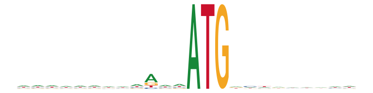

### Highly translated Annotated ATGs have a Kozak consensus sequence

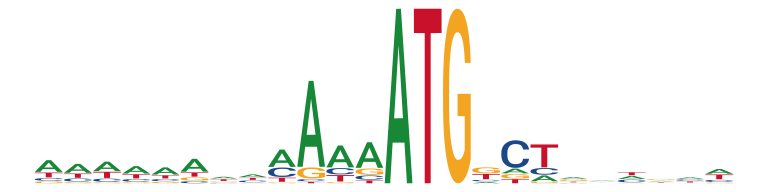

[figure not shown]

### Cytoplasmic Ribosome Annotated ATGs have a Kozak consensus sequence

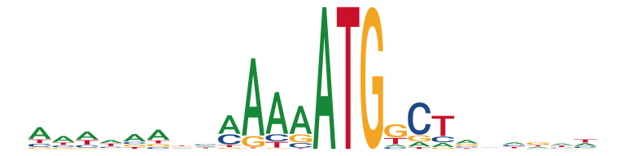

[figure not shown]

### Many cytoribo genes are highly translated (5% highest)

Venn diagram.

There are many duplicate cytoRibo genes in Sc, and in the Geraschenko dataset these are both included

Both duplicates were discarded from the Weinberg & Shah et al ribosome profiling dataset, which is why we stopped using it.

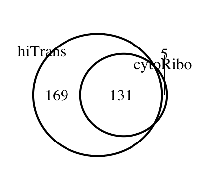

### Downstream ATGs don’t have a consensus

First downstream ATG

[figure not shown]

### Downstream ATGs in frame and highly translated don’t have a consensus

Except for 3rd-codon-position bias.

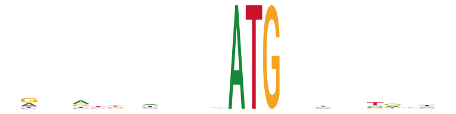

## Calculate Information content and scores of consensus motif

### Calculate a wide and a narrow consensus sequence

Calculate motif score against the position weight matrix (pwm) for both **narrow** (-4 from ATG through to ATG) and **wide** (-10 from ATG) kozak consensus motif. These motifs are taken from the top 5% highly translated genes.

### Estimate the information content

Using the sequence logo, details on https://en.wikipedia.org/wiki/Sequence_logo

```
## # A tibble: 6 x 4
##   Genes    ATG   Width  Infon
##   <chr>    <chr> <chr>  <dbl>
## 1 All      aATG  narrow 0.688
## 2 HiTrans  aATG  narrow 2.47
## 3 CytoRibo aATG  narrow 3.11
## 4 All      d1ATG narrow 0.152
## 5 HiTrans  d1ATG narrow 0.210
## 6 CytoRibo d1ATG narrow 0.299
```

### Estimate information content per base across start context

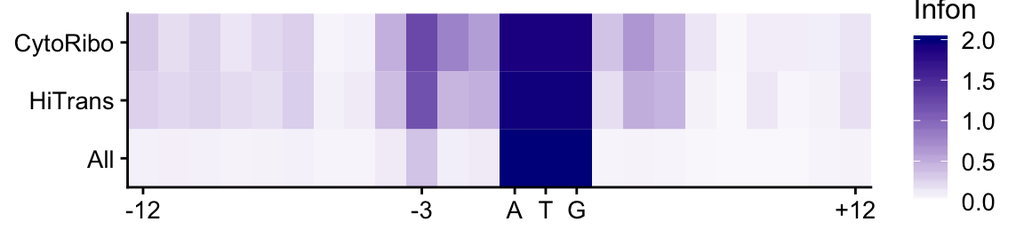

### Calculate scores of aATG, dATG, uATG against Kozak consensus

We calculate scores using Biostrings::PWMscoreStartingAt.

The best description I could find of this method is: https://support.bioconductor.org/p/61520/

It is just the sum of the matrix product of the PWM with the sequence.

Write scores to file *scores_kozak_Sc.txt*.

```
## # A tibble: 6,571 x 11
##    Gene  aATG.scorekn d1.scorekn u1.scorekn aATG.scorekw d1.scorekw
##    <chr>        <dbl>      <dbl>      <dbl>        <dbl>      <dbl>
##  1 YAL0…        1          0.754         NA        0.920      0.690
##  2 YAL0…        0.880      0.982         NA        0.843      0.878
##  3 YAL0…        0.946      0.833         NA        0.902      0.800
##  4 YAL0…        0.875      0.807         NA        0.805      0.759
##  5 YAL0…        0.897      0.779         NA        0.876      0.744
##  6 YAL0…        0.911      0.839         NA        0.865      0.771
##  7 YAL0…        0.959      0.897         NA        0.861      0.774
##  8 YAL0…        0.771      0.782         NA        0.771      0.761
##  9 YAL0…        0.788      0.804         NA        0.748      0.731
## 10 YAL0…        0.921      0.845         NA        0.892      0.710
## # ... with 6,561 more rows, and 5 more variables: u1.scorekw <dbl>,
## #   d1vsan <dbl>, u1vsan <dbl>, d1vsaw <dbl>, u1vsaw <dbl>
```

### Plot against narrow consensus (-4 to ATG)

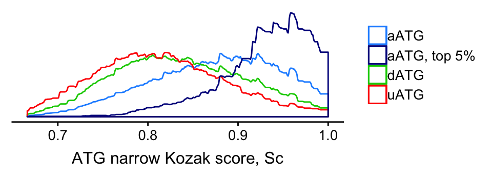

### Plot against wide consensus (-10 to ATG)

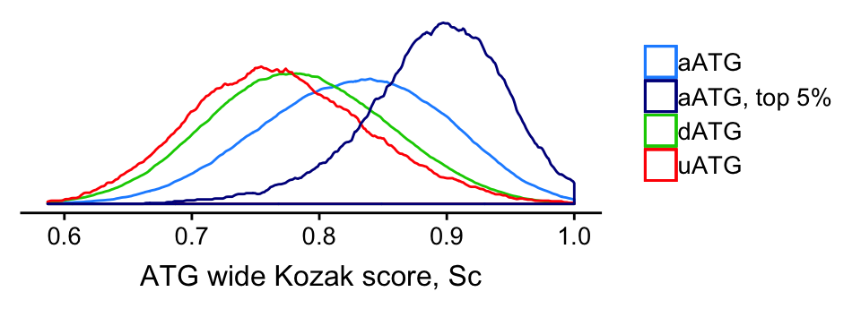

## Mutual information of different positions around ATG

### For all annotated genes

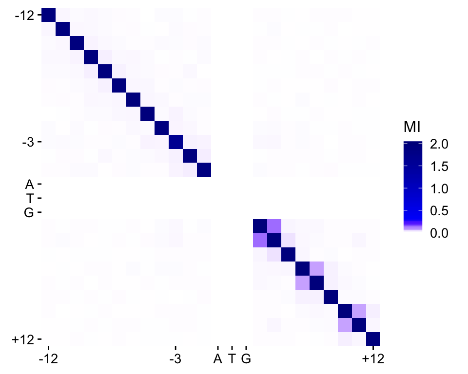

### For highly translated genes

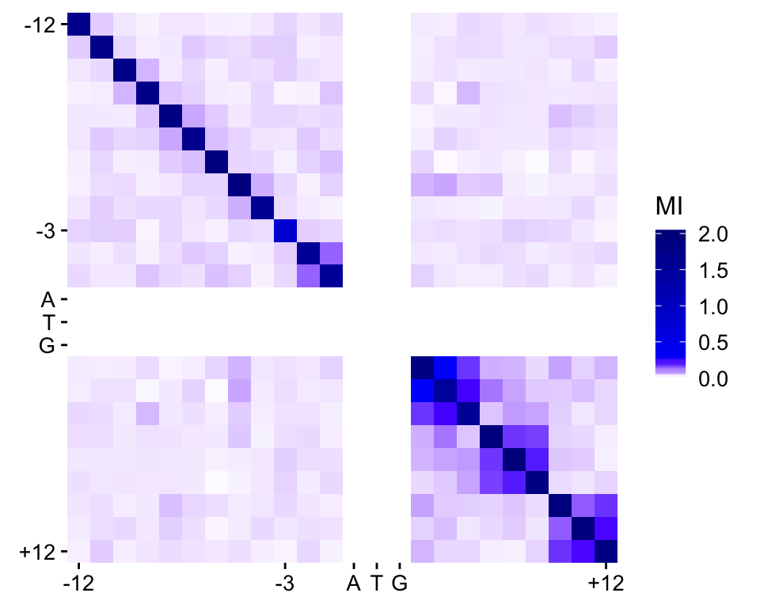

### For cytoplasmic ribosomal proteins

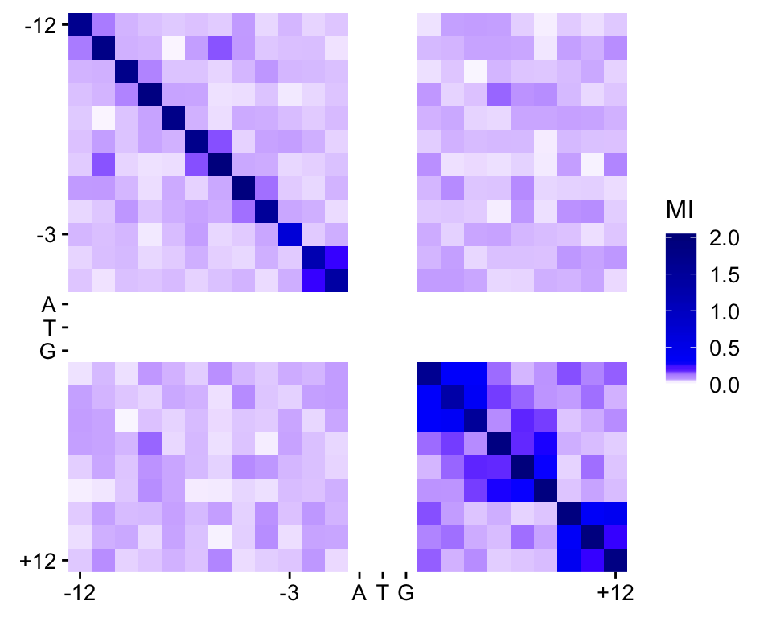

### What is the -2 correlation in cyto ribo genes?

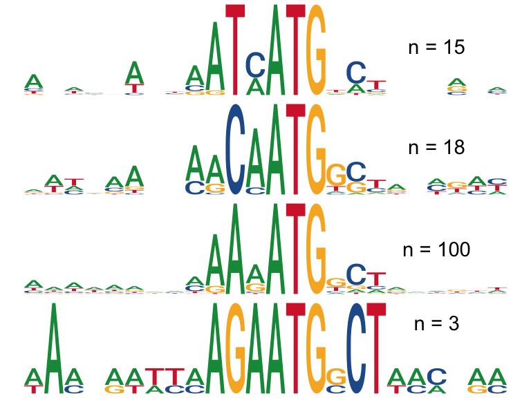

There are definitely correlations there.

## uATGs inhibit translation of the main ORF

### uATGs are barely associated with lower absolute translation

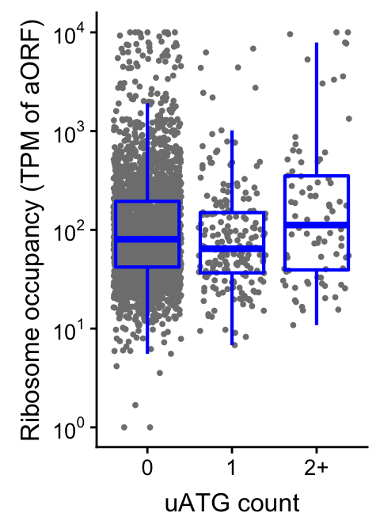

### uATGs are barely associated with lower translation efficiency

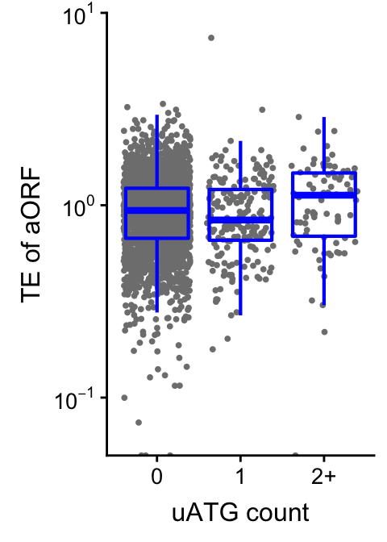

### uATGs weakly associated with lower translation efficiency might be over 20nt from TSS

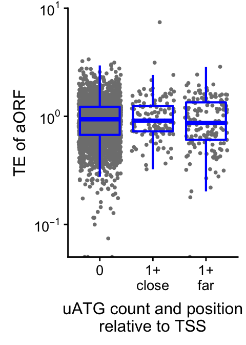

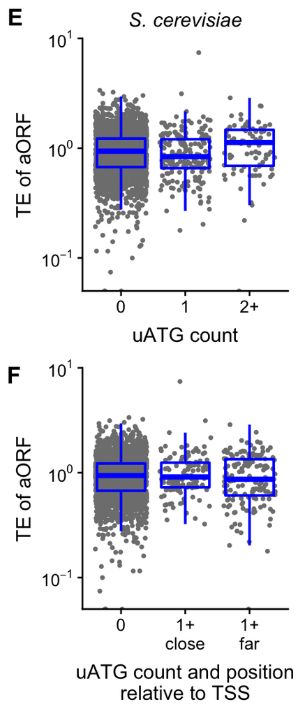

### uATG score does not affect TE

We suspect that uATG is associated with lower TE if the uATG has

- position at least 20nt downstream from TSS
- higher score

This figure shows that, *for genes with only 1 uATG*, this correlation is weak and opposite to expected.

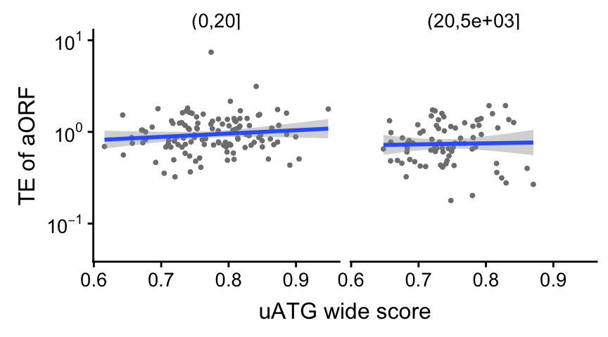

## Compare aATG and dATG context by gene

### Most dATG scores are less than aATG scores

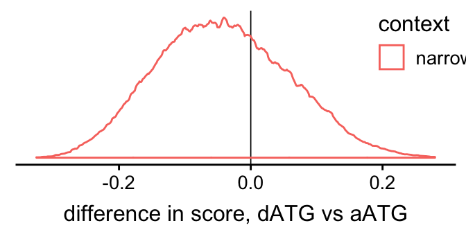

### For highly translated genes, most dATG narrow scores are much less than aATG

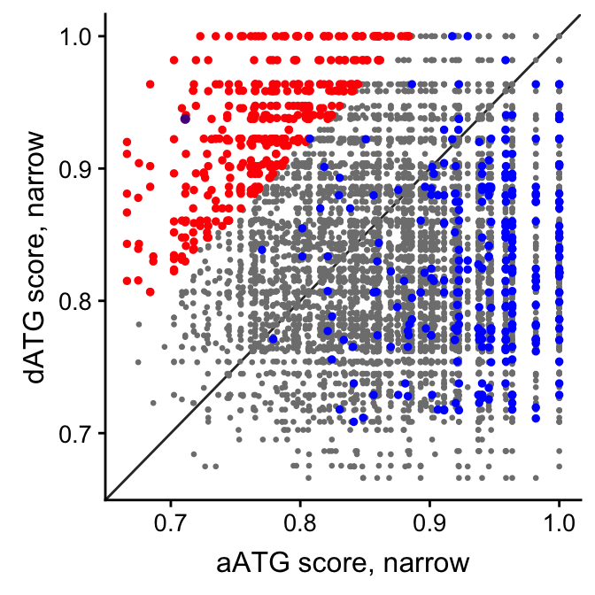

Red: high dATG vs aATG **Kozak** score. Blue: highly translated. Purple: both.

R = 0.008

### For highly translated genes, most dATG wide scores are much less than aATG

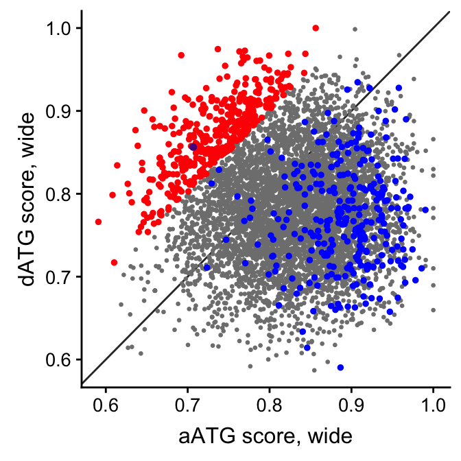

Red: high dATG vs aATG **Kozak** score. Blue: highly translated. Purple: both.

R = 0.023

#### There may be some trend but it is weak

Boxplots show enough_RNA only.

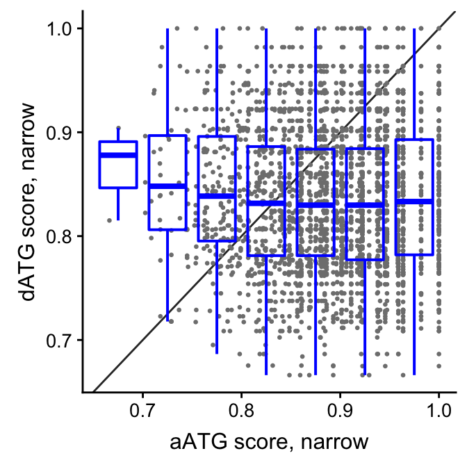

## Genes with unusual dATG vs aATG narrow score

Those genes are in this list:

```
## # A tibble: 400 x 3
##    Gene      aATG.scorekn d1.scorekn
##    <chr>            <dbl>      <dbl>
##  1 YPL096C-A        0.684      0.964
##  2 YDR514C          0.702      0.982
##  3 YLR082C          0.723      1
##  4 YER156C          0.735      1
##  5 YJL164C          0.719      0.982
##  6 YPL108W          0.745      1
##  7 YOR105W          0.666      0.920
##  8 YPR002C-A        0.729      0.982
##  9 YDR513W          0.754      1
## 10 YBL079W          0.718      0.964
## # ... with 390 more rows
```

- SRL2 / YLR082C unknown function, localized to nucleus and cytoplasm
- HSF1 / YGL073W heat shock transcription factor 1, known to shuttle between nucleus and cytoplasm, weird reported mitochondrial localization
- YER156C, unknown function, localizes to the nucleus and cytoplasm in a large-scale study
- INP1 / YMR204C, peripheral membrane protein of peroxisomes
- CIN8 / YEL061C, kinesin motor protein involved in mitosis. Reported mitochondrial localization.
- ERI1 / YPL096C-A, ER-associated Ras Inhibitor
- GRX2 / YDR513W, Cytoplasmic/mitochondrial glutaredoxin, predicted mito localization sequence before 2nd in-frame ATG
- YNR025C, Dubious open reading frame
- PHO86 / YJL117W, ER-resident protein involved in packaging phosphate transporter Pho84 to vesicles
- TPK1 / YJL164C, cAMP-dependent protein kinase catalytic subunit, localizes to nucleus and cytoplasm

These genes are also highly translated:

```
## # A tibble: 1 x 3
##   Gene    aATG.scorekn d1.scorekn
##   <chr>          <dbl>      <dbl>
## 1 YNL244C        0.711      0.937
```

There is no clear pattern in these.

### dATG in frame with ATG, narrow - CHECK against dual-localized papers!

Files with high difference in narrow score, filtered for reasonable amounts of RNA, in frame.

```
## # A tibble: 43 x 3
##    Gene    aATG.scorekn d1.scorekn
##    <chr>          <dbl>      <dbl>
##  1 YER156C        0.735      1
##  2 YDR513W        0.754      1
##  3 YHR070W        0.712      0.940
##  4 YLR357W        0.675      0.904
##  5 YGR094W        0.756      0.959
##  6 YDL122W        0.702      0.896
##  7 YDL125C        0.806      1
##  8 YLR403W        0.782      0.964
##  9 YGR029W        0.777      0.959
## 10 YDR388W        0.763      0.940
## 11 YOR116C        0.765      0.940
## 12 YDR248C        0.729      0.902
## 13 YLR389C        0.726      0.897
## 14 YKR016W        0.711      0.881
## 15 YNL247W        0.753      0.923
## # ... with 28 more rows
```

- YER156C, copper-regulated putative protein of unknown function, nuclear/cyto localization
- GRX2 / YDR513W, glutaredoxin, dual-localized mito and cyto from in-frame start codons.
- TRM5 / YHR070W, tRNAmethyltransferase, dual-localized mito and cyto from in-frame start codons
- RSC2 / YLR357W, chromatin remodeler
- VAS1 / YGR094W, Valyl tRNA synthase, localized to cytoplasm and mitochondria
- UBP1 / YDL122W, Ubiquitin-specific protease, localizes to cytoplasm and ER
- HNT1 / YDL125C, Adenosine 5’-monophosphoramidase, reported nuclear/cyto localization
- SFP1 / YLR403W, transcription regulator of ribosomal biogenesis genes, nuclear/cyto localization
- ERV1 / YGR029W, mitochondrial sulfhydryl oxidase
- RVS167 / YDR388W, Calmodulin-binding actin-associated protein
- STE23 / YLR389C, Metalloprotease, mitochondrial
- YDR248C, Putative gluconokinase localized to cytoplasm and vacuole
- ERB1 / YMR049C, Eukaryotic Ribosome Biogenesis protein, nucleolar.
- YNL247W, Cysteinyl-tRNA synthetase, localized to cytoplasm and mitochondria

### dATG out of frame with ATG

Files with high difference in narrow score, filtered for reasonable amounts of RNA, out of frame.

```
## # A tibble: 76 x 3
##    Gene    aATG.scorekn d1.scorekn
##    <chr>          <dbl>      <dbl>
##  1 YJL164C        0.719      0.982
##  2 YBL079W        0.718      0.964
##  3 YNL244C        0.711      0.937
##  4 YGR231C        0.738      0.964
##  5 YDR083W        0.781      1
##  6 YLR258W        0.764      0.982
##  7 YPR004C        0.745      0.958
##  8 YPL203W        0.779      0.982
##  9 YKL004W        0.675      0.878
## 10 YNL258C        0.798      1
## # ... with 66 more rows
```

In addition:

- TPK1 / YJL164C, cAMP-dependent protein kinase catalytic subunit
- PHB2 / YGR231C, inner mitochondrial membrane chaperone
- NUP170 / YBL079W, Subunit of nuclear pore complex

### dATG in frame with ATG, wide

Files with high difference in wide score, filtered for reasonable amounts of RNA, in frame. Saved to *dvsaATG_highdiffw_inframe_Sc.txt*.

```
## # A tibble: 39 x 3
##    Gene    aATG.scorekw d1.scorekw
##    <chr>          <dbl>      <dbl>
##  1 YER156C        0.767      0.966
##  2 YBL057C        0.720      0.901
##  3 YDR513W        0.736      0.913
##  4 YLR357W        0.669      0.838
##  5 YIL064W        0.680      0.847
##  6 YDL125C        0.799      0.967
##  7 YNL247W        0.727      0.894
##  8 YGR029W        0.770      0.932
##  9 YHR070W        0.688      0.842
## 10 YDR248C        0.710      0.861
## # ... with 29 more rows
```

### dATG out of frame with ATG, wide

Files with high difference in wide score, filtered for reasonable amounts of RNA, out of frame. Saved to *dvsaATG_highdiffw_outframe_Sc.txt*.

[output not shown]

## Compare score difference to localization predictions

We need to put the corresponding SacCer proteome through mitofates in order to run these analyses.

### Load predictions from mitofates

In input file *SacCer_mitofates_parsed.table.txt*.

### SacCer Genes with high dATG vs aATG score are not enriched in mitochondrial presequences

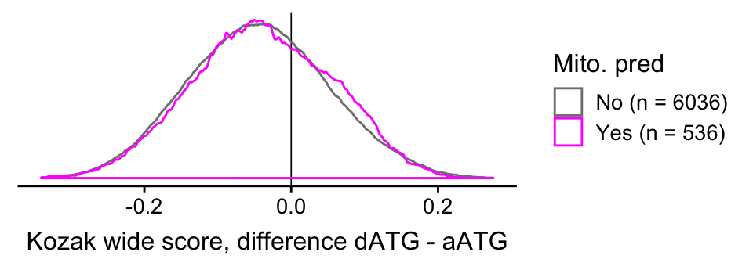

### There are no correlations between d1 score, d1 frame, and localization

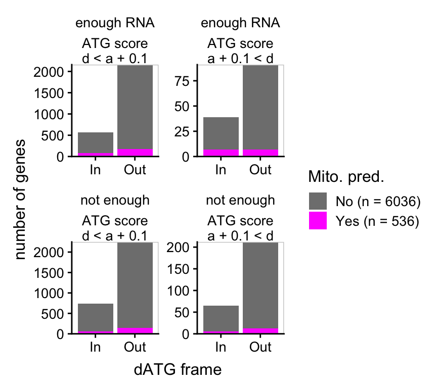

### Count dATG vs ATG score, d1 frame, mito pre, enough RNA

```
## # A tibble: 16 x 5
## # Groups:   enoughR, d1vsaw0p1, d1.framefac [?]
##    enoughR d1vsaw0p1 d1.framefac Pred_preseq     n
##    <fct>   <fct>     <fct>       <fct>       <int>
##  1 Yes     d1lo      In          No            480
##  2 Yes     d1lo      In          Yes            84
##  3 Yes     d1lo      Out         No           1990
##  4 Yes     d1lo      Out         Yes           170
##  5 Yes     d1hi      In          No             32
##  6 Yes     d1hi      In          Yes             7
##  7 Yes     d1hi      Out         No             84
##  8 Yes     d1hi      Out         Yes             7
##  9 No      d1lo      In          No            678
## 10 No      d1lo      In          Yes            60
## 11 No      d1lo      Out         No           2108
## 12 No      d1lo      Out         Yes           140
## 13 No      d1hi      In          No             60
## 14 No      d1hi      In          Yes             5
## 15 No      d1hi      Out         No            199
## 16 No      d1hi      Out         Yes            13
```

### SacCer mito-localized genes also do not have a distinctive aATG context

Although the +5 T is striking.

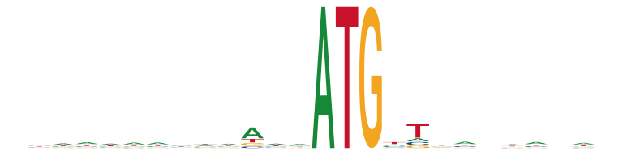

Back to table of contents